# Lab Exercises 6 Solutions

## Question 1

The table below is taken from BDA. It contains results of a survey on bicycle traffic around Berkeley, CA in 1993. From the table in BDA we consider only the first four rows of data for residential streets. This consists of bicycle counts on a particular day on different streets around Berkeley. Also recorded is whether the street has a certified bicycle lane or not.

| Bike route? | Bicycle count | Bike route? | Bicycle count |
| --- | --- | --- | --- |
| Yes | 16 | Yes | 55 |
| Yes | 9 | No | 12 |
| Yes | 10 | No | 1 |
| Yes | 13 | No | 2 |
| Yes | 19 | No | 4 |
| Yes | 20 | No | 9 |
| Yes | 18 | No | 7 |
| Yes | 17 | No | 9 |
| Yes | 35 | No | 8 |

*We wish to compare the amount of bicycle traffic on the sections of road that are designated bike routes, with that for roads without bike routes. Type the data in R:*

```r
y <- c(16,9,10,13,19,20,18,17,35,55) # for bike route
z <- c(12,1,2,4,9,7,9,8) # for non-bike route
```

#### (a) Consider the group bike route =‘Yes’ (Y) first. What distribution are the bicycle counts most likely to follow?

Assuming the counts are independent and identically distributed, we would use a Poisson distribution here. So, $Y \sim Poisson (\theta_{Y})$

#### (b) Assume that the bicycle counts on bike routes are independent and identically distributed for different streets. What is the conditional likelihood formula for the counts Y?

$$p(y \mid \theta_{Y}) = \prod \frac{\theta_{Y}^{y_i} exp(-\theta_{Y})}{y_i!} = \frac{\theta_{Y}^{n\bar{y}} exp(-n\theta_{Y})}{\prod y_i!}\propto \theta_{Y}^{212}exp(-10\theta_{Y})$$

This is in the form of a $Gamma(213,10)$ density in $\theta_{Y}$.

#### (c) What prior information do we have? Construct a prior distribution for $\theta_{Y}$ the parameter of interest for the counts y.

In this case we seem to have no prior information about $\theta_{Y}$. Our preferred noninformative prior is $Gamma(1,0)$.

#### (d) Update the prior with the observed counts to find the posterior distribution for $\theta_{Y} \mid y$. Generate an estimate and 95% interval for $\theta_{Y} \mid y$.

The posterior for $\theta_{Y} \mid y$ is $Gamma (213, 10)$. $E(\theta_{Y} \mid y) = 213/10 = 21.3$.

A 95% interval is $(18.5353872, 24.2539794)$

#### (e) Let Z = bicycle counts on non-bike routes. How can we compare Y and Z?

Naturally, we compare $\theta_{Y}$ and $\theta_{Z}$, the rates of bicycle usage for bike routes and non-bike routes.

#### (f) Estimate a 95% confidence interval on the difference $\theta_{Y} – \theta_{Z}$. What conclusions can you draw based on this interval?

Rather than attempt to find the true distribution of $\theta_{Y} – \theta_{Z} \mid y,z$ we can use Monte Carlo simulation here. Just simulate from $\theta_{Y} \mid y \sim Gamma(213,10)$ and $\theta_{Z} \mid z \sim Gamma (53, 8)$. Then simply subtract each iterate of $\theta_{Z}$ from each iterate of $\theta_{Y}$ obtaining a sample from $\theta_{Y} – \theta_{Z} \mid y,z$.

i.e.

```r
ty <- rgamma(10000,213,10)
tz <- rgamma(10000,53,8)
tymz <- ty-tz
```

The quantile function is then used as follows

```r
quantile(tymz,c(0.025,0.975))
```

```
##     2.5%    97.5%
## 11.36021 18.08009
```

A point estimate is

```r
mean(tymz)
```

```
## [1] 14.66528
```

A histogram follows

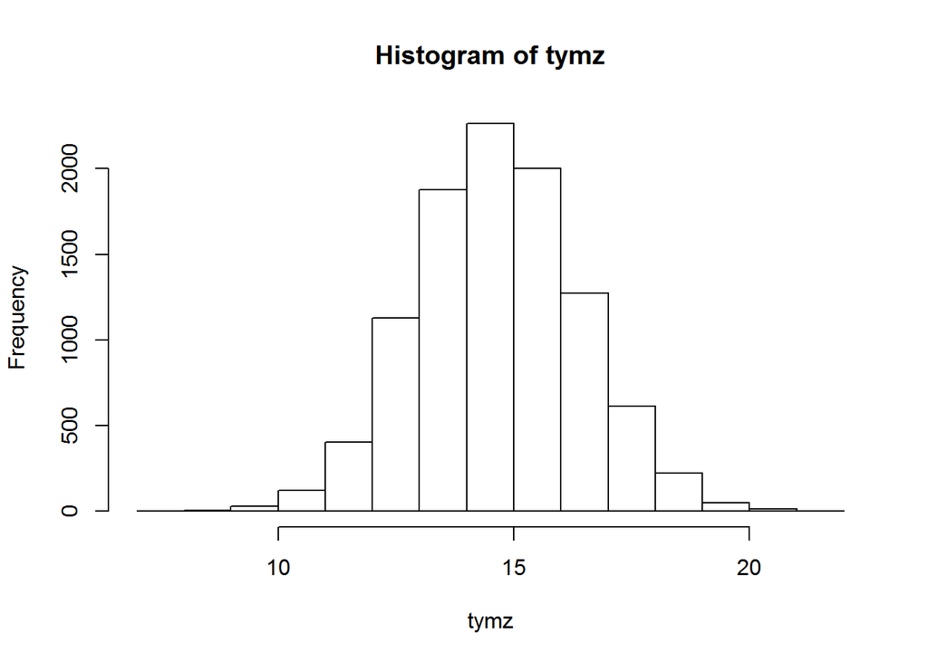

```r
hist(tymz)
```

Clearly bike routes are used significantly more than non-bike routes.

#### (g) Estimate the probability that $\theta_{Y} – \theta_{Z}$ is greater than 10 given the data.

Using the sample in (f)

```r
length(tymz[tymz>10])/length(tymz) # (or: mean(tymz>10)!)
```

```
## [1] 0.9968
```

We are very confident that bike usage is at least 10 per day per street more on bike routes than non-bike routes.

```r
model_summary <- tidy(t.test(y,z,"greater",10))
model_summary
```

```
##   estimate estimate1 estimate2 statistic   p.value parameter conf.low
## 1     14.7      21.2       6.5  1.023048 0.1644724  10.65815  6.42522
##   conf.high                  method alternative
## 1       Inf Welch Two Sample t-test     greater
```

## Question 2

#### (a) The likelihood contributes a $Gamma (213, 10)$ to the posterior.

A $Gamma(a,b)$ prior means the posterior is $\theta_{Y} \mid y \sim Gamma (212+a, 10+b)$. So we have $Gamma(0,0)$ prior $ \theta_{Y} \mid y \sim Gamma (212, 10)$ and $Gamma(0.5,0)$ prior $ \theta_{Y} \mid y \sim Gamma (212.5, 10)$. 95% intervals for these are (using $m=10,000,000$ – even then not always enough for 2 dps!)

| Prior | Posterior | 95% interval θ_y\|y | 95% interval θ_y - θ_z\|y,z | Pr(θ_y - θ_z > 10) |
| --- | --- | --- | --- | --- |
| 0,0 | 212,10 | 18.44, 24.15 | 11.38, 18.09 | 0.997 |
| 0.5,0 | 212.5,10 | 18.49, 24.20 | 11.36, 18.09 | 0.997 |
| 1,0 | 213,10 | 18.54, 24.25 | 11.33, 18.08 | 0.997 |

Results seem quite insensitive to these prior choices.

R code for Gamma(0,0)

```r
qgamma(c(0.025,0.975),212,10)
```

```
## [1] 18.44211 24.14725
```

```r
ty1 <- rgamma(10000,212,10)
tz1 <- rgamma(10000,52,8)
tymz1 <- ty1-tz1
```

The quantile function is then used as follows

```r
quantile(tymz1,c(0.025,0.975)) ##
```

```
##     2.5%    97.5%
## 11.39905 18.16639
```

```r
length(tymz1[tymz1>10])/length(tymz1)   ###
```

```
## [1] 0.9972
```

For Gamma(0.5,0)

```r
qgamma(c(0.025,0.975),212.5,10)
```

```
## [1] 18.48875 24.20062
```

```r
ty2 <- rgamma(10000,212.5,10)
tz2 <- rgamma(10000,52.5,8)
tymz2 <- ty2-tz2
```

The quantile function is then used as follows

```r
quantile(tymz2, c(0.025,0.975))
```

```
##     2.5%    97.5%
## 11.40764 18.03338
```

```r
length(tymz2[tymz2>10])/length(tymz2)
```

```
## [1] 0.9969
```

#### (b) Under a $Gamma(20,2)$ prior $\theta_{Y} \mid y \sim Gamma (232, 12)$ and under a $Gamma(20,3)$ prior $\theta_{Z} \mid z \sim Gamma (72, 11)$

For informative priors $Gamma(20,2)$ for $Y$ and $Gamma(20,3)$ for $Z$

For Y:

```r
qgamma(c(0.025,0.975),232,12)
```

```
## [1] 16.92540 21.89907
```

```r
ty3 <- rgamma(10000,232,12)
tz3 <- rgamma(10000,72,11)
tymz3 <- ty3-tz3
```

The quantile function is then used as follows:

```r
quantile(tymz3, c(0.025,0.975))
```

```
##      2.5%     97.5%
##  9.848747 15.780359
```

```r
length(tymz3[tymz3>10])/length(tymz3)
```

```
## [1] 0.9679
```

The table now is

| Prior | Posterior | 95% interval θ_y\|y | 95% interval θ_y - θ_z\|y,z | Pr(θ_y - θ_z > 10) |
| --- | --- | --- | --- | --- |
| 0,0 | 212,10 | 18.44, 24.15 | 11.38, 18.09 | 0.997 |
| 0.5,0 | 212.5,10 | 18.49, 24.20 | 11.36, 18.09 | 0.997 |
| 1,0 | 213,10 | 18.54, 24.25 | 11.33, 18.08 | 0.997 |
| 20,2 | 232, 12 | 16.93, 21.90 | 9.91, 15.74 | 0.971 |
| 20,3 | 72, 11 |  |  |  |

The posteriors for $\theta_{Y} \mid y$ are shown below. The blue line is the $Gamma(232,12)$ from the expert prior. The posteriors based on the 3 candidate noninformative priors are almost indistinguishable.

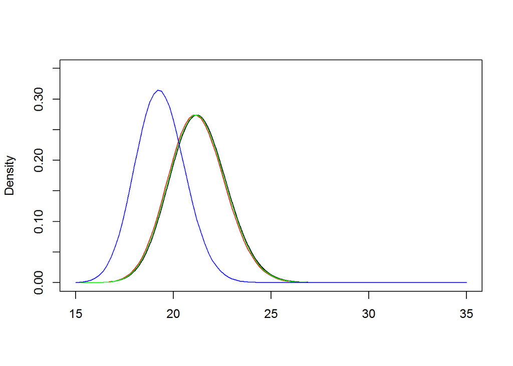